# Detection mode project: Tables and figures for publication

Author

Martina Brayley, Reuben Frost

Published

July 18, 2025

## 1 Set-Up

### 1.1 Table and figure structure

**Main figures**

**Table 1:** Tumour characteristics of interval and screen-detected breast cancers

**Figure 2:** Mammographic density by detection mode and tumour characteristics

**Figure 3:** Mammographic density by risk factor

**Figure 4:** Forest plot of OR estimates for interval breast cancers based on 3 complexities of models

**Supplementary material**

**Supplementary Table 1:** Comparison of derived detection mode and regsitry detection mode

**Supplementary Table 2:** Multivariable model predicting log(Mammographic Density), both adjusted and non-adjusted for age at mammogram

**Supplementary Table 4:** OR estimates for interval breast cancer for tumour characteristics

## 2 Main figures and tables

### 2.1 Table 1 - Tumour characteristics of interval and screen-detected breast cancers

| **Characteristic** | **Interval** N = 755 <sup>1</sup> | **Screen-Detected** N = 1,185 <sup>1</sup> | **95% CI** <sup>2</sup> | **p-value** <sup>3</sup> |
| --- | --- | --- | --- | --- |
| Age at recruitment | 55.13 (7.11) | 55.19 (6.93) |  |  |
| Age at mammogram | 58.56 (5.39) | 58.49 (5.37) |  |  |
| Unknown | 354 (47) | 395 (33) |  |  |
| Age at diagnosis | 62.32 (6.80) | 61.61 (6.38) | 0.99, 1.02 | 0.3 |
| Time from recruitment to diagnosis (years) | 7.19 (3.69) | 6.42 (3.58) | 1.01, 1.13 | 0.021 |
| Year of diagnosis |  |  |  |  |
| 2004-2008 | 96 (13) | 182 (15) | — |  |
| 2009-2013 | 255 (34) | 496 (42) | 0.56, 1.17 | 0.3 |
| 2014-2018 | 404 (54) | 507 (43) | 0.58, 1.75 | >0.9 |
| Invasive status |  |  |  |  |
| DCIS | 47 (6.2) | 261 (22) | — |  |
| Invasive | 708 (94) | 924 (78) | 0.94, 2.86 | 0.080 |
| Grade |  |  |  |  |
| 1 | 88 (12) | 250 (21) | — |  |
| 2 | 335 (44) | 477 (40) | 1.14, 2.10 | 0.006 |
| 3 | 264 (35) | 187 (16) | 1.72, 3.53 | <0.001 |
| Missing | 68 (9.0) | 271 (23) |  |  |
| Morphology type |  |  |  |  |
| Ductal | 549 (73) | 698 (59) | — |  |
| Lobular | 95 (13) | 119 (10) | 0.69, 1.35 | 0.8 |
| Mixed | 25 (3.3) | 43 (3.6) | 0.53, 1.58 | 0.8 |
| Other | 39 (5.2) | 64 (5.4) | 0.57, 1.47 | 0.7 |
| Missing | 47 (6.2) | 261 (22) |  |  |
| Node status |  |  |  |  |
| Negative | 304 (40) | 601 (51) | — |  |
| Positive | 234 (31) | 194 (16) | 1.41, 2.38 | <0.001 |
| Missing | 217 (29) | 390 (33) |  |  |
| Tumour size (mm) |  |  |  |  |
| <21 | 336 (45) | 656 (55) | — |  |
| 21-50 | 225 (30) | 162 (14) | 1.55, 2.65 | <0.001 |
| 50+ | 31 (4.1) | 15 (1.3) | 1.43, 5.73 | 0.003 |
| Missing | 163 (22) | 352 (30) |  |  |
| ER status |  |  |  |  |
| Positive | 525 (70) | 791 (67) | — |  |
| Negative | 137 (18) | 87 (7.3) | 1.16, 2.56 | 0.007 |
| Missing | 93 (12) | 307 (26) |  |  |
| PR status |  |  |  |  |
| Positive | 283 (37) | 375 (32) | — |  |
| Negative | 175 (23) | 154 (13) | 0.59, 1.18 | 0.3 |
| Missing | 297 (39) | 656 (55) |  |  |
| HER2 status |  |  |  |  |
| Positive | 102 (14) | 92 (7.8) | — |  |
| Negative | 524 (69) | 725 (61) | 0.71, 1.44 | >0.9 |
| Missing | 129 (17) | 368 (31) |  |  |

<sup>1</sup> Mean (SD); n (%)  
<sup>2</sup> CI = Confidence Interval  
<sup>3</sup> p-value from logistic regression multivariate model of all listed variables

### 2.2 Figure 2 - Mammographic density by mode of detection and tumour characteristics

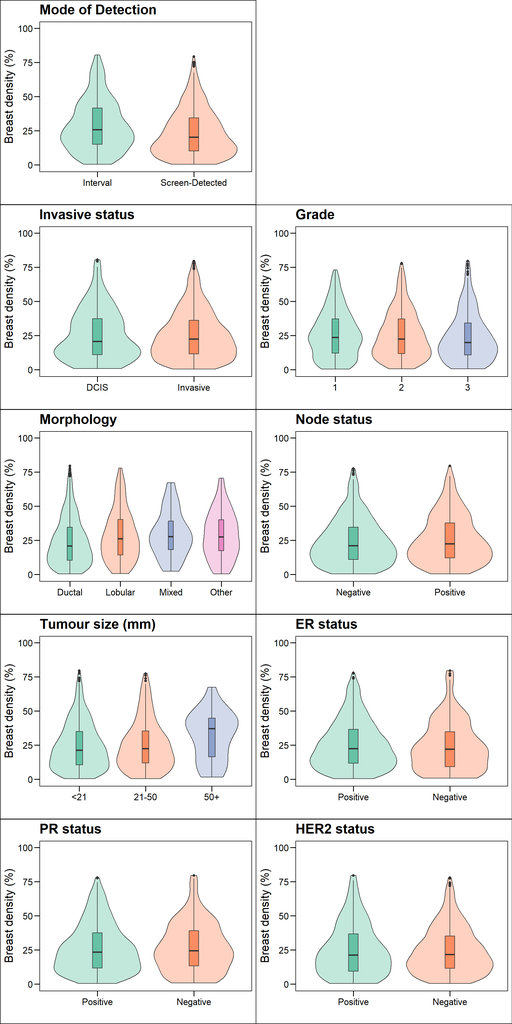

### 2.3 Figure 2 - Mammographic density by mode of detection and tumour characteristics (ALTERNATE)

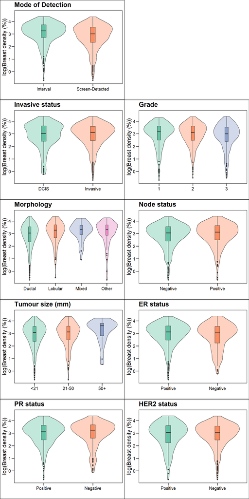

### 2.4 Figure 3 - Mammographic density by risk factors

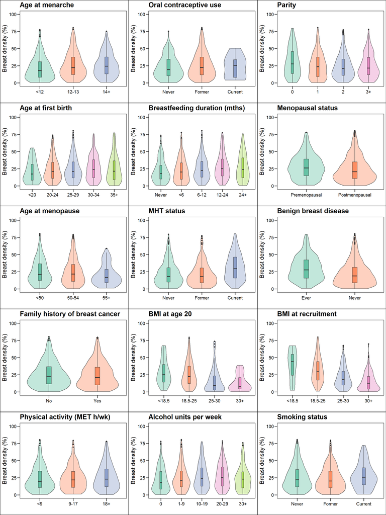

### 2.5 Figure 3 - Mammographic density by risk factors (ALTERNATE)

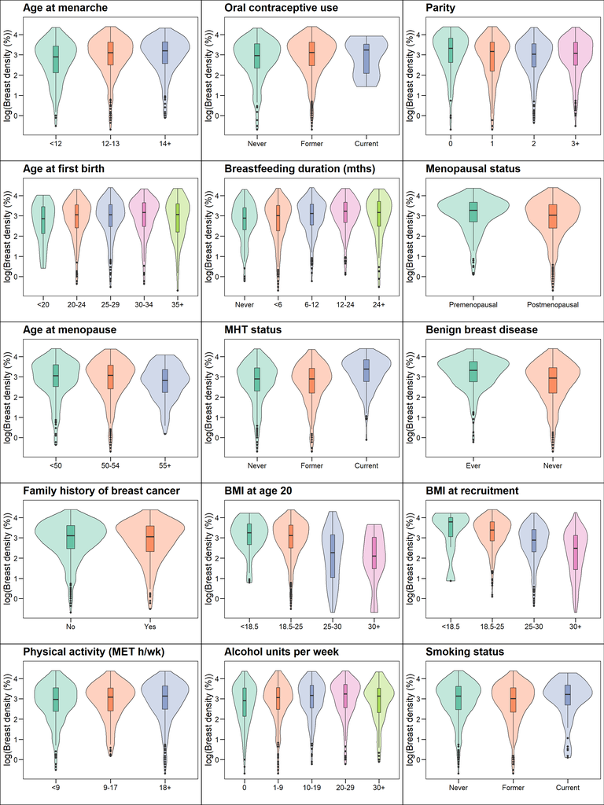

### 2.6 Figure 4 - Forest plot

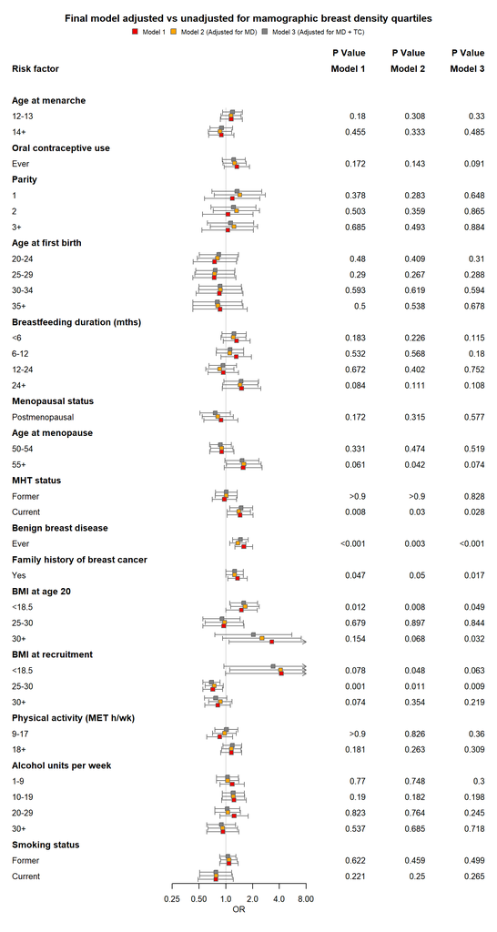

## 3 Supplementary figures and tables

### 3.1 Supplementary Table 1

```r
#| echo: false

# Read in data
df_mod <- readRDS("Q:/SHARED/USERS/MBrayley/Screening/data/dm_df_include_unknown.rds")

# use row percentages and rename reg_sd levels to align with dmode

dmode_crosstab_tb <- df_mod |>
  filter(source_dm2 != "reg_sd") |>
  mutate(

    reg_sd = if_else(is.na(reg_sd), "NA", reg_sd),

    reg_sd = factor(reg_sd,
                    levels = c("N", "Y", "U", "NA"),
                    labels = c("Interval", "Screen-Detected", "Unknown", "No Data")),

    d_dmode = case_when(
      ancat_dmode_v2 == "I" ~ "Interval",
      ancat_dmode_v2 == "SD" ~ "Screen-Detected",
      TRUE ~ "Other"
    ),

    d_dmode = factor(d_dmode, levels = c("Interval", "Screen-Detected", "Other"))

  ) |>
  tbl_cross(
    row = reg_sd,
    col = d_dmode,
    percent = "cell"
  ) |>
  bold_labels()

#dmode_crosstab_tb |> show_header_names()


dmode_crosstab_tb <- dmode_crosstab_tb |>
  modify_header(
    label ~ "**Registry Detection Mode**"
  ) |>
  modify_spanning_header(all_stat_cols() ~ "**Derived Detection Mode**" # Rename column variable
  )


dmode_crosstab_tb <- dmode_crosstab_tb |>
  modify_table_body(
    ~ .x |>
      filter(label != "reg_sd") |>  # Remove rows where the label matches the old variable name
      mutate(stat_1 = if_else(row_number() == n(), stat_1, gsub("\\(.*", "", stat_1)),
             stat_2 = if_else(row_number() == n(), stat_2, gsub("\\(.*", "", stat_2)),
             stat_3 = if_else(row_number() == n(), stat_3, gsub("\\(.*", "", stat_3)),
             )
  )

dmode_crosstab_tb
```

| **Registry Detection Mode** | **Derived Detection Mode** Interval | **Derived Detection Mode** Screen-Detected | **Derived Detection Mode** Other | **Derived Detection Mode** **Total** |
| --- | --- | --- | --- | --- |
| Interval | 501 | 0 | 397 | 898 (34%) |
| Screen-Detected | 33 | 852 | 119 | 1,004 (38%) |
| Unknown | 17 | 6 | 56 | 79 (3.0%) |
| No Data | 62 | 50 | 522 | 634 (24%) |
| Total | 613 (23%) | 908 (35%) | 1,094 (42%) | 2,615 (100%) |

```r
dmode_crosstab_tb |>
  as_flex_table() |>
  flextable::save_as_docx(path = "../outputs/figures/supplement/supplementary_table_1.docx")
```

### 3.2 Supplementary Table 2

| **Characteristic** | **N = 1,191** <sup>1</sup> | **Unadjusted** **Beta** | **Unadjusted** **95% CI** <sup>2</sup> | **Unadjusted** **p-value** | **Adjusted for age at mammogram** **Beta** | **Adjusted for age at mammogram** **95% CI** <sup>2</sup> | **Adjusted for age at mammogram** **p-value** |
| --- | --- | --- | --- | --- | --- | --- | --- |
| Mode of detection |  |  |  |  |  |  |  |
| Screen-Detected | 790 (66) | — | — |  | — | — |  |
| Interval | 401 (34) | 0.282002231774028 | 0.167930063492915, 0.39607440005514 | 0.00000139659474806363 | 0.284197766718281 | 0.171567156954836, 0.396828376481726 | 0.000000846705328909703 |
| Age at menarche |  |  |  |  |  |  |  |
| <12 | 265 (24) | — | — |  | — | — |  |
| 12-13 | 544 (50) | 0.238171223121844 | 0.0983384629006895, 0.378003983342999 | 0.000860011884800794 | 0.245651704972748 | 0.107448037965322, 0.383855371980173 | 0.000506837628990491 |
| 14+ | 277 (26) | 0.273659645561428 | 0.11326351824667, 0.434055772876186 | 0.000842779321745122 | 0.277007957031137 | 0.118508414946956, 0.435507499115319 | 0.00062807506044135 |
| Oral contraception status |  |  |  |  |  |  |  |
| No | 201 (17) | — | — |  | — | — |  |
| Yes | 988 (83) | 0.146118722182709 | 0.00118871725202002, 0.291048727113398 | 0.0481532693133364 | 0.0350022594811859 | -0.114006438901939, 0.184010957864311 | 0.644978241716587 |
| Parity |  |  |  |  |  |  |  |
| 0 | 154 (13) | — | — |  | — | — |  |
| 1 | 137 (12) | -0.269912106506778 | -0.490021221097815, -0.0498029919157415 | 0.0162853347690467 | -0.265352710022793 | -0.482882944762833, -0.0478224752827523 | 0.0168527392775608 |
| 2 | 628 (53) | -0.222476937106858 | -0.391006219118337, -0.0539476550953792 | 0.00971494665428534 | -0.184689259452996 | -0.351799829795647, -0.0175786891103453 | 0.03033041449288 |
| 3+ | 272 (23) | -0.18749350162982 | -0.376498009913135, 0.00151100665349518 | 0.0518568765476234 | -0.153772564008944 | -0.340955584907005, 0.0334104568891175 | 0.107277365511506 |
| Age at first birth |  |  |  |  |  |  |  |
| <20 | 48 (4.7) | — | — |  | — | — |  |
| 20-24 | 328 (32) | 0.193565080584132 | -0.0953596839255535, 0.482489845093817 | 0.18892865166401 | 0.21525675626142 | -0.0709134399711788, 0.501426952494019 | 0.140244402567498 |
| 25-29 | 407 (39) | 0.201778942218894 | -0.0835437157335331, 0.487101600171321 | 0.165525129942472 | 0.217273042202208 | -0.0652613365254922, 0.499807420929908 | 0.13160116025211 |
| 30-34 | 179 (17) | 0.273745771898495 | -0.0301426686336285, 0.577634212430618 | 0.0774182041987249 | 0.241440154807369 | -0.0597037628355813, 0.54258407245032 | 0.115970477763797 |
| 35+ | 69 (6.7) | 0.163511529318046 | -0.187883936122156, 0.514906994758249 | 0.36141042509489 | 0.11376371599749 | -0.234730485178377, 0.462257917173358 | 0.521942553647686 |
| Breastfeeding duration (mths) |  |  |  |  |  |  |  |
| Never breastfed | 183 (18) | — | — |  | — | — |  |
| <6 | 342 (33) | 0.0096116858510723 | -0.16019239735304, 0.179415769055184 | 0.911579920387213 | 0.0106509136467754 | -0.157720045044934, 0.179021872338485 | 0.901236280194627 |
| 6-12 | 210 (20) | 0.20382237033883 | 0.0163366660824114, 0.391308074595248 | 0.0331397330528889 | 0.19052691533787 | 0.0045261832447456, 0.376527647430993 | 0.0446894148245827 |
| 12-24 | 215 (21) | 0.311008827305157 | 0.124541031683695, 0.497476622926619 | 0.00109999107623419 | 0.281404269202552 | 0.0960223721396061, 0.466786166265499 | 0.00296285450239594 |
| 24+ | 87 (8.4) | 0.189178358661432 | -0.0522586192806295, 0.430615336603494 | 0.124468539774164 | 0.148512251879819 | -0.0915979945831981, 0.388622498342836 | 0.225141900171394 |
| Menopausal status |  |  |  |  |  |  |  |
| Premenopausal | 233 (20) | — | — |  | — | — |  |
| Postmenopausal | 958 (80) | -0.228071711687485 | -0.364689953708645, -0.0914534696663238 | 0.00108587386406144 | -0.0251957736820236 | -0.187502181226787, 0.13711063386274 | 0.760749317663468 |

[output cut: 67 more lines]

<sup>1</sup> n (%)  
<sup>2</sup> CI = Confidence Interval

### 3.3 Supplementary Table 3

| **Characteristic** | **Distribution by detection mode** **Interval** N = 755 <sup>1</sup> | **Distribution by detection mode** **Screen-Detected** N = 1,185 <sup>1</sup> | **Model 1** **OR** <sup>2,3</sup> | **Model 1** **95% CI** <sup>3</sup> | **Model 1** **p-value** | **Model 2** **OR** <sup>4,3</sup> | **Model 2** **95% CI** <sup>3</sup> | **Model 2** **p-value** | **Model 3** **OR** <sup>3</sup> | **Model 3** **95% CI** <sup>3</sup> | **Model 3** **p-value** | **Model 4** **OR** <sup>3</sup> | **Model 4** **95% CI** <sup>3</sup> | **Model 4** **p-value** |
| --- | --- | --- | --- | --- | --- | --- | --- | --- | --- | --- | --- | --- | --- | --- |
| Age at menarche |  |  |  |  |  |  |  |  |  |  |  |  |  |  |
| <12 | 153 (20) | 260 (22) | — | — |  | — | — |  | — | — |  | — | — |  |
| 12-13 | 369 (49) | 523 (44) | 1.18970366071405 | 0.92394262581602, 1.53503322410981 | 0.179609328924742 | 1.14382300581778 | 0.884011000801894, 1.48266036253312 | 0.308138274041658 | 1.2121236949329 | 0.91815515453064, 1.60344160676607 | 0.175970314549626 | 1.15122941834905 | 0.8679881084324, 1.52954569548545 | 0.329589288902445 |
| 14+ | 169 (22) | 286 (24) | 0.894086907287415 | 0.666552655348388, 1.19916363837784 | 0.454672234932706 | 0.862752185921053 | 0.639828682989089, 1.16303688349621 | 0.332614746532762 | 0.942085765975539 | 0.68289042382258, 1.29981937953166 | 0.71621058558112 | 0.889948396807779 | 0.641410229740586, 1.23449807108156 | 0.484927185915177 |
| Missing | 64 (8.5) | 116 (9.8) |  |  |  |  |  |  |  |  |  |  |  |  |
| Oral contraceptive use |  |  |  |  |  |  |  |  |  |  |  |  |  |  |
| Never | 95 (13) | 182 (15) | — | — |  | — | — |  | — | — |  | — | — |  |
| Ever | 659 (87) | 1,001 (84) | 1.22819890285804 | 0.916516559421078, 1.65364420365478 | 0.171770728443431 | 1.25260417608993 | 0.928757629333117, 1.69726576295272 | 0.142755685621645 | 1.30742784226834 | 0.949704368764123, 1.80822622634752 | 0.102444819254853 | 1.32796417278707 | 0.9577810905919, 1.85009902762645 | 0.090983794093035 |
| Missing | 1 (0.1) | 2 (0.2) |  |  |  |  |  |  |  |  |  |  |  |  |
| Parity |  |  |  |  |  |  |  |  |  |  |  |  |  |  |
| 0 | 97 (13) | 161 (14) | — | — |  | — | — |  | — | — |  | — | — |  |
| 1 | 86 (11) | 125 (11) | 1.33621460368277 | 0.699568121070013, 2.5424299263455 | 0.377944938721181 | 1.43423430942869 | 0.74043509593909, 2.76971153933478 | 0.283256699633665 | 1.1521841296893 | 0.567328152471258, 2.32684688767494 | 0.693611084010371 | 1.18196773568244 | 0.575150726816525, 2.41751673403025 | 0.647694896528601 |
| 2 | 408 (54) | 630 (53) | 1.21977248251415 | 0.680066651830209, 2.17738548112227 | 0.502604120724911 | 1.32170682466923 | 0.725599642103971, 2.39720819340982 | 0.359437720048704 | 0.998353726117664 | 0.526268677820562, 1.87895495850381 | 0.995944404209512 | 1.05765635753339 | 0.550373765333946, 2.01727169626801 | 0.865456868484406 |
| 3+ | 164 (22) | 269 (23) | 1.13136871147845 | 0.621270221766052, 2.04938779036766 | 0.684707756216023 | 1.23835020172697 | 0.669355331854847, 2.27949902488816 | 0.49339431730072 | 0.992560111126576 | 0.515433022352854, 1.89716100518623 | 0.982050959510269 | 1.05085691303916 | 0.537587908061347, 2.03930503136475 | 0.883886726731275 |
| Age at first birth |  |  |  |  |  |  |  |  |  |  |  |  |  |  |
| <20 | 35 (4.6) | 45 (3.8) | — | — |  | — | — |  | — | — |  | — | — |  |
| 20-24 | 197 (26) | 308 (26) | 0.833601518065666 | 0.503874445232693, 1.38795033553409 | 0.480225036004774 | 0.804216931094891 | 0.479904386285524, 1.35509798357244 | 0.409447491769801 | 0.765071333562332 | 0.442580798957426, 1.33263619906166 | 0.339853081199348 | 0.748784826636921 | 0.42916947178981, 1.31520646137281 | 0.310119198669623 |
| 25-29 | 256 (34) | 421 (36) | 0.761937123797945 | 0.461507087591846, 1.26588591625276 | 0.289556779911419 | 0.747301922042956 | 0.447362548387807, 1.2550724354384 | 0.26711425817551 | 0.733518790138873 | 0.424710768699113, 1.27650275437509 | 0.268523378478442 | 0.739838025175775 | 0.42519268075331, 1.29607852749951 | 0.288093438473163 |
| 30-34 | 122 (16) | 174 (15) | 0.861204672989829 | 0.498693952128368, 1.49431408070238 | 0.592771987652466 | 0.867810003824113 | 0.496385425702825, 1.52329303364772 | 0.619437023284884 | 0.834072009550656 | 0.460464779878971, 1.51998392193696 | 0.550748608385012 | 0.848271867141011 | 0.463959754508447, 1.55921025446389 | 0.593927040959584 |
| 35+ | 46 (6.1) | 71 (6.0) | 0.80338118757236 | 0.425020521413558, 1.51934056002195 | 0.499828054381923 | 0.815574560261925 | 0.42581002428854, 1.56237403599804 | 0.538097567113028 | 0.830853175723575 | 0.414986550712754, 1.66719013127597 | 0.600919849300964 | 0.861167549624382 | 0.425351902077958, 1.74674810421719 | 0.677875835969348 |
| Missing | 99 (13) | 166 (14) |  |  |  |  |  |  |  |  |  |  |  |  |
| Breastfeeding duration (mths) |  |  |  |  |  |  |  |  |  |  |  |  |  |  |
| Never breastfed | 101 (13) | 179 (15) | — | — |  | — | — |  | — | — |  | — | — |  |
| <6 | 223 (30) | 319 (27) | 1.23618091912011 | 0.905757591979394, 1.69237729692915 | 0.18335619690558 | 1.21803961542764 | 0.886197020179118, 1.67893867822449 | 0.225943959146272 | 1.34597374371459 | 0.956980780142148, 1.8994187946376 | 0.0891063042876961 | 1.32441626235948 | 0.934751043236925, 1.88243748836197 | 0.115394234895675 |
| 6-12 | 131 (17) | 200 (17) | 1.11765427257907 | 0.788661562775208, 1.5862628736026 | 0.532380952402841 | 1.10952399125753 | 0.777124021531673, 1.5863404360652 | 0.567795274485561 | 1.30963411950685 | 0.893496002684359, 1.92384288213298 | 0.16770071831326 | 1.30662153520436 | 0.884679362075393, 1.93395852869494 | 0.179807356508859 |
| 12-24 | 131 (17) | 244 (21) | 0.926402691082788 | 0.650298247682073, 1.32124558071355 | 0.672292175048794 | 0.857026148001365 | 0.597454583453254, 1.23039723325099 | 0.40217288617132 | 1.00996313800387 | 0.685468489063955, 1.49010433401271 | 0.960058314563226 | 0.938287194943279 | 0.632297277462521, 1.39381760589848 | 0.751921468978657 |
| 24+ | 72 (9.5) | 82 (6.9) | 1.48475329194526 | 0.949021785140093, 2.32516237831303 | 0.08354455767818 | 1.44885716725202 | 0.91881478044759, 2.28790496598709 | 0.110824795520355 | 1.56399243495586 | 0.959560927149307, 2.55224467772722 | 0.072871723219384 | 1.50301296254525 | 0.91519584371436, 2.47245514394385 | 0.107712275677089 |
| Missing | 97 (13) | 161 (14) |  |  |  |  |  |  |  |  |  |  |  |  |
| Menopausal status |  |  |  |  |  |  |  |  |  |  |  |  |  |  |
| Premenopausal | 242 (32) | 355 (30) | — | — |  | — | — |  | — | — |  | — | — |  |

[output cut: 85 more lines]

<sup>1</sup> n (%)  
<sup>2</sup> Model 1: Age at menarche, Menopause, Age at menopause, MHT status, Oral contraceptive use, Parity, Age at first birth, Breast feeding duration (mths), Benign breast disease, Family history of breast cancer, BMI at recruitment, BMI at age 20, Physical activity (MET h/wk), Alcohol units per week, Smoking status, Age at Diagnosis, Time from Recruitment to BC diagnosis, Year of diagnosis  
<sup>3</sup> OR = Odds Ratio, CI = Confidence Interval  
<sup>4</sup> Model 2: Age at menarche, Menopause, Age at menopause, MHT status, Oral contraceptive use, Parity, Age at first birth, Breast feeding duration (mths), Benign breast disease, Family history of breast cancer, BMI at recruitment, BMI at age 20, Physical activity (MET h/wk), Alcohol units per week, Smoking status, Age at Diagnosis, Time from Recruitment to BC diagnosis, Year of diagnosis Percent Mammographic density (quartiles), Time from Mammographic density measurement to BRCA diagnosis.

### 3.4 Supplementary Table 4

TC descriptives by detection mode, logistic regression of TC with detection mode (same principal as risk factor analysis but multiple exposures are TC)

| **Characteristic** | **Distribution by detection mode** **Interval** N = 755 <sup>1</sup> | **Distribution by detection mode** **Screen-Detected** N = 1,185 <sup>1</sup> | **Model** **OR** <sup>2</sup> | **Model** **95% CI** <sup>2</sup> | **Model** **p-value** |
| --- | --- | --- | --- | --- | --- |
| Invasive status |  |  |  |  |  |
| DCIS | 47 (6.2) | 261 (22) | — | — |  |
| Invasive | 708 (94) | 924 (78) | 1.56273398206463 | 0.904933537692987, 2.70742861578673 | 0.109993944336353 |
| Grade |  |  |  |  |  |
| 1 | 88 (12) | 250 (21) | — | — |  |
| 2 | 335 (44) | 477 (40) | 1.55903670572305 | 1.15281756668936, 2.11980839010339 | 0.00423260583742127 |
| 3 | 264 (35) | 187 (16) | 2.41000203469726 | 1.69225231892957, 3.4469473348734 | 0.00000123392411098458 |
| Missing | 68 (9.0) | 271 (23) |  |  |  |
| Morphology type |  |  |  |  |  |
| Ductal | 549 (73) | 698 (59) | — | — |  |
| Lobular | 95 (13) | 119 (10) | 0.940958928592262 | 0.672047485372323, 1.31273016995573 | 0.721358799560706 |
| Mixed | 25 (3.3) | 43 (3.6) | 0.915712350638881 | 0.529545493875612, 1.55285020812785 | 0.747374852746166 |
| Other | 39 (5.2) | 64 (5.4) | 0.892993550217292 | 0.552549540995673, 1.42625681205155 | 0.639064325853048 |
| Missing | 47 (6.2) | 261 (22) |  |  |  |
| Node status |  |  |  |  |  |
| Negative | 304 (40) | 601 (51) | — | — |  |
| Positive | 234 (31) | 194 (16) | 1.671633521459 | 1.29233519032716, 2.1621255691034 | 0.0000902577436776707 |
| Missing | 217 (29) | 390 (33) |  |  |  |
| Tumour size (mm) |  |  |  |  |  |
| <21 | 336 (45) | 656 (55) | — | — |  |
| 21-50 | 225 (30) | 162 (14) | 2.11584520475006 | 1.62667183799653, 2.75568872458245 | 0.0000000246010895845165 |
| 50+ | 31 (4.1) | 15 (1.3) | 3.11404685789473 | 1.59909408261829, 6.29819316187855 | 0.00108548395021369 |
| Missing | 163 (22) | 352 (30) |  |  |  |
| ER status |  |  |  |  |  |
| Positive | 525 (70) | 791 (67) | — | — |  |
| Negative | 137 (18) | 87 (7.3) | 1.68324512616536 | 1.14228818587848, 2.48762735314283 | 0.008655672942842 |
| Missing | 93 (12) | 307 (26) |  |  |  |
| PR status |  |  |  |  |  |
| Positive | 283 (37) | 375 (32) | — | — |  |
| Negative | 175 (23) | 154 (13) | 0.860240848297712 | 0.607546654977772, 1.21374489789363 | 0.393385393297041 |
| Missing | 297 (39) | 656 (55) |  |  |  |
| HER2 status |  |  |  |  |  |
| Positive | 102 (14) | 92 (7.8) | — | — |  |
| Negative | 524 (69) | 725 (61) | 1.0261300437722 | 0.727760005171562, 1.4483742407957 | 0.883076801701265 |
| Missing | 129 (17) | 368 (31) |  |  |  |

<sup>1</sup> n (%)  
<sup>2</sup> OR = Odds Ratio, CI = Confidence Interval

## 4 Miscellaneous

### 4.1 Associations of BBD with TC and MOD

WARNINGS?

```r
# Try and find associations with tumour characteristics


model <- df |>
  glm(formula = as.formula(paste0("d_bbd_lab ~", paste0(tumour_char_tr,collapse = "+"))), family = "binomial")


tbl_regression(x = model,
                 exponentiate = T) |>
  add_global_p() |>
  print()
```

| **Characteristic** | **OR** <sup>1</sup> | **95% CI** <sup>1</sup> | **p-value** |
| --- | --- | --- | --- |
| d_inv_status |  |  | 0.7 |
| 0 | — | — |  |
| 1 | 1.12 | 0.68, 1.83 |  |
| d_grade_tr |  |  | 0.2 |
| 1 | — | — |  |
| 2 | 0.87 | 0.65, 1.16 |  |
| 3 | 0.68 | 0.48, 0.97 |  |
| Missing | 0.89 | 0.38, 2.01 |  |
| d_morph4_tr_lab |  |  | 0.7 |
| Ductal | — | — |  |
| Lobular | 1.12 | 0.80, 1.56 |  |
| Mixed: ductal and other | 1.10 | 0.64, 1.84 |  |
| Other | 1.24 | 0.80, 1.91 |  |
| d_pos_nodes_tr_lab |  |  | 0.2 |
| Negative | — | — |  |
| Positive | 0.85 | 0.65, 1.12 |  |
| Missing | 1.17 | 0.86, 1.58 |  |
| d_tmsize_tr_lab |  |  | 0.3 |
| <21 | — | — |  |
| 21-50 | 1.03 | 0.78, 1.35 |  |
| 50+ | 1.83 | 0.96, 3.47 |  |
| Missing | 1.02 | 0.71, 1.44 |  |
| d_er_tr_lab |  |  | 0.6 |
| Positive | — | — |  |
| Negative | 1.21 | 0.81, 1.79 |  |
| Missing | 0.98 | 0.59, 1.60 |  |
| d_pr_tr_lab |  |  | 0.9 |
| Positive | — | — |  |
| Negative | 0.91 | 0.64, 1.28 |  |
| Missing | 0.98 | 0.76, 1.25 |  |
| d_her2_tr_lab |  |  | 0.3 |
| Positive | — | — |  |
| Negative | 0.78 | 0.55, 1.11 |  |
| Missing | 0.90 | 0.57, 1.41 |  |

<sup>1</sup> OR = Odds Ratio, CI = Confidence Interval

```r
# Testing BBD History association with MOD with/without removing Grade

# Full model
model <- df %>%
  glm(formula = d_dmode_n ~ d_R1menopause_lab3 + d_age_meno_tr_lab
      + d_R1hrt_tr_lab
      + d_parity_lab + d_agebirth1_tr_lab + d_age_menarche_lab + d_ocstatus2_lab
      + d_bbd_lab + d_fambrca_lab
      + d_R1alcohol_units_lab + d_R1smokingstatus_lab
      + d_bmi_entry_lab + d_R1physmet_leis_who_lab + d_bmi_20_lab + d_bf_dur_tr_lab
      + diagage + d_R1toBC_y + yeardiag
      + d_md_qrt + d_MDtoBC_lab
      + d_inv_status + d_grade_tr + d_morph4_tr_lab + d_pos_nodes_tr_lab
      + d_tmsize_tr_lab + d_er_tr_lab + d_pr_tr_lab + d_her2_tr_lab,
            family = binomial(link = "logit"))

tbl_regression(x = model, exponentiate = T) |>
  modify_table_body(
    ~ .x %>%
      dplyr::filter(.data$variable == "d_bbd_lab")
  )
```

| **Characteristic** | **OR** <sup>1</sup> | **95% CI** <sup>1</sup> | **p-value** |
| --- | --- | --- | --- |
| d_bbd_lab |  |  |  |
| No | — | — |  |
| Yes | 1.59 | 1.27, 2.00 | <0.001 |

<sup>1</sup> OR = Odds Ratio, CI = Confidence Interval

```r
# Model without TC
model <- df %>%
  glm(formula = d_dmode_n ~ d_R1menopause_lab3 + d_age_meno_tr_lab
      + d_R1hrt_tr_lab
      + d_parity_lab + d_agebirth1_tr_lab + d_age_menarche_lab + d_ocstatus2_lab
      + d_bbd_lab + d_fambrca_lab
      + d_R1alcohol_units_lab + d_R1smokingstatus_lab
      + d_bmi_entry_lab + d_R1physmet_leis_who_lab + d_bmi_20_lab + d_bf_dur_tr_lab
      + diagage + d_R1toBC_y + yeardiag
      + d_md_qrt + d_MDtoBC_lab,
            family = binomial(link = "logit"))

tbl_regression(x = model, exponentiate = T) |>
  modify_table_body(
    ~ .x %>%
      dplyr::filter(.data$variable == "d_bbd_lab")
  )
```

| **Characteristic** | **OR** <sup>1</sup> | **95% CI** <sup>1</sup> | **p-value** |
| --- | --- | --- | --- |
| d_bbd_lab |  |  |  |
| No | — | — |  |
| Yes | 1.37 | 1.11, 1.68 | 0.003 |

<sup>1</sup> OR = Odds Ratio, CI = Confidence Interval

```r
# Including Grade
model <- df %>%
  glm(formula = d_dmode_n ~ d_R1menopause_lab3 + d_age_meno_tr_lab
      + d_R1hrt_tr_lab
      + d_parity_lab + d_agebirth1_tr_lab + d_age_menarche_lab + d_ocstatus2_lab
      + d_bbd_lab + d_fambrca_lab
      + d_R1alcohol_units_lab + d_R1smokingstatus_lab
      + d_bmi_entry_lab + d_R1physmet_leis_who_lab + d_bmi_20_lab + d_bf_dur_tr_lab
      + diagage + d_R1toBC_y + yeardiag
      + d_md_qrt + d_MDtoBC_lab
      + d_grade_tr,
            family = binomial(link = "logit"))

tbl_regression(x = model, exponentiate = T) |>
  modify_table_body(
    ~ .x %>%
      dplyr::filter(.data$variable == "d_bbd_lab")
  )
```

| **Characteristic** | **OR** <sup>1</sup> | **95% CI** <sup>1</sup> | **p-value** |
| --- | --- | --- | --- |
| d_bbd_lab |  |  |  |
| No | — | — |  |
| Yes | 1.55 | 1.25, 1.94 | <0.001 |

<sup>1</sup> OR = Odds Ratio, CI = Confidence Interval

### 4.2 Associations of Family History of BC with TC and MOD

```r
# Try and find associations with tumour characteristics


model <- df |>
  glm(formula = as.formula(paste0("d_fambrca_lab ~", paste0(tumour_char_tr,collapse = "+"))), family = "binomial")


tbl_regression(x = model,
                 exponentiate = T) |>
  print()
```

| **Characteristic** | **OR** <sup>1</sup> | **95% CI** <sup>1</sup> | **p-value** |
| --- | --- | --- | --- |
| d_inv_status |  |  |  |
| 0 | — | — |  |
| 1 | 0.81 | 0.46, 1.43 | 0.5 |
| d_grade_tr |  |  |  |
| 1 | — | — |  |
| 2 | 0.99 | 0.72, 1.37 | 0.9 |
| 3 | 0.88 | 0.60, 1.30 | 0.5 |
| Missing | 0.87 | 0.30, 2.23 | 0.8 |
| d_morph4_tr_lab |  |  |  |
| Ductal | — | — |  |
| Lobular | 0.80 | 0.54, 1.17 | 0.3 |
| Mixed: ductal and other | 1.06 | 0.58, 1.83 | 0.8 |
| Other | 0.86 | 0.50, 1.42 | 0.6 |
| d_pos_nodes_tr_lab |  |  |  |
| Negative | — | — |  |
| Positive | 1.03 | 0.77, 1.38 | 0.8 |
| Missing | 1.02 | 0.72, 1.43 | 0.9 |
| d_tmsize_tr_lab |  |  |  |
| <21 | — | — |  |
| 21-50 | 1.07 | 0.79, 1.45 | 0.6 |
| 50+ | 0.88 | 0.38, 1.86 | 0.8 |
| Missing | 0.92 | 0.60, 1.36 | 0.7 |
| d_er_tr_lab |  |  |  |
| Positive | — | — |  |
| Negative | 0.93 | 0.59, 1.44 | 0.7 |
| Missing | 1.53 | 0.88, 2.58 | 0.12 |
| d_pr_tr_lab |  |  |  |
| Positive | — | — |  |
| Negative | 1.11 | 0.75, 1.62 | 0.6 |
| Missing | 0.86 | 0.65, 1.13 | 0.3 |
| d_her2_tr_lab |  |  |  |
| Positive | — | — |  |
| Negative | 1.29 | 0.87, 1.96 | 0.2 |
| Missing | 0.95 | 0.55, 1.64 | 0.9 |

<sup>1</sup> OR = Odds Ratio, CI = Confidence Interval

```r
# Testing BBD History association with MOD with/without removing Grade

# Full model
model <- df %>%
  glm(formula = d_dmode_n ~ d_R1menopause_lab3 + d_age_meno_tr_lab
      + d_R1hrt_tr_lab
      + d_parity_lab + d_agebirth1_tr_lab + d_age_menarche_lab + d_ocstatus2_lab
      + d_bbd_lab + d_fambrca_lab
      + d_R1alcohol_units_lab + d_R1smokingstatus_lab
      + d_bmi_entry_lab + d_R1physmet_leis_who_lab + d_bmi_20_lab + d_bf_dur_tr_lab
      + diagage + d_R1toBC_y + yeardiag
      + d_md_qrt + d_MDtoBC_lab
      + d_inv_status + d_grade_tr + d_morph4_tr_lab + d_pos_nodes_tr_lab
      + d_tmsize_tr_lab + d_er_tr_lab + d_pr_tr_lab + d_her2_tr_lab,
            family = binomial(link = "logit"))

tbl_regression(x = model, exponentiate = T) |>
  modify_table_body(
    ~ .x %>%
      dplyr::filter(.data$variable == "d_fambrca_lab")
  )
```

| **Characteristic** | **OR** <sup>1</sup> | **95% CI** <sup>1</sup> | **p-value** |
| --- | --- | --- | --- |
| d_fambrca_lab |  |  |  |
| No | — | — |  |
| Yes | 1.36 | 1.06, 1.74 | 0.017 |

<sup>1</sup> OR = Odds Ratio, CI = Confidence Interval

```r
# Model without TC
model <- df %>%
  glm(formula = d_dmode_n ~ d_R1menopause_lab3 + d_age_meno_tr_lab
      + d_R1hrt_tr_lab
      + d_parity_lab + d_agebirth1_tr_lab + d_age_menarche_lab + d_ocstatus2_lab
      + d_bbd_lab + d_fambrca_lab
      + d_R1alcohol_units_lab + d_R1smokingstatus_lab
      + d_bmi_entry_lab + d_R1physmet_leis_who_lab + d_bmi_20_lab + d_bf_dur_tr_lab
      + diagage + d_R1toBC_y + yeardiag
      + d_md_qrt + d_MDtoBC_lab,
            family = binomial(link = "logit"))

tbl_regression(x = model, exponentiate = T) |>
  modify_table_body(
    ~ .x %>%
      dplyr::filter(.data$variable == "d_fambrca_lab")
  )
```

| **Characteristic** | **OR** <sup>1</sup> | **95% CI** <sup>1</sup> | **p-value** |
| --- | --- | --- | --- |
| d_fambrca_lab |  |  |  |
| No | — | — |  |
| Yes | 1.26 | 1.00, 1.58 | 0.050 |

<sup>1</sup> OR = Odds Ratio, CI = Confidence Interval

```r
# Adding grade
model <- df %>%
  glm(formula = d_dmode_n ~ d_R1menopause_lab3 + d_age_meno_tr_lab
      + d_R1hrt_tr_lab
      + d_parity_lab + d_agebirth1_tr_lab + d_age_menarche_lab + d_ocstatus2_lab
      + d_bbd_lab + d_fambrca_lab
      + d_R1alcohol_units_lab + d_R1smokingstatus_lab
      + d_bmi_entry_lab + d_R1physmet_leis_who_lab + d_bmi_20_lab + d_bf_dur_tr_lab
      + diagage + d_R1toBC_y + yeardiag
      + d_md_qrt + d_MDtoBC_lab
      + d_grade_tr,
            family = binomial(link = "logit"))

tbl_regression(x = model, exponentiate = T) |>
  modify_table_body(
    ~ .x %>%
      dplyr::filter(.data$variable == "d_fambrca_lab")
  )
```

| **Characteristic** | **OR** <sup>1</sup> | **95% CI** <sup>1</sup> | **p-value** |
| --- | --- | --- | --- |
| d_fambrca_lab |  |  |  |
| No | — | — |  |
| Yes | 1.36 | 1.07, 1.73 | 0.013 |

<sup>1</sup> OR = Odds Ratio, CI = Confidence Interval

### 4.3 Counting individuals by ordering of events in MOD

```
MOD_order
             Interval: MD -> R1                 Interval: no MD
                            139                             354
             Interval: R1 -> MD       Screen-Detected: MD -> R1
                            262                             318
         Screen-Detected: no MD Screen-Detected: R1 -> BC -> MD
                            395                               1
Screen-Detected: R1 -> MD -> BC
                            471
```

### 4.4 Summary of time differences

```
Summary of time from R1 to breast cancer for Interval cancers
    Min.  1st Qu.   Median     Mean  3rd Qu.     Max.
 0.07671  4.21644  7.64658  7.19002 10.19973 13.73771

Summary of time from R1 to mammogram for Interval cancers
   Min. 1st Qu.  Median    Mean 3rd Qu.    Max.    NA's
-8.5765 -0.4645  1.0137  1.6663  3.9781  9.7514     354

Summary of time from mammogram to breast cancer for Interval cancers
   Min. 1st Qu.  Median    Mean 3rd Qu.    Max.    NA's
  0.326   1.759   2.660   3.711   5.164  14.192     354

Summary of time from R1 to breast cancer for Screen-Detected cancers
    Min.  1st Qu.   Median     Mean  3rd Qu.     Max.
 0.03014  3.43989  6.42740  6.42287  9.37260 13.86849

Summary of time from R1 to mammogram for Screen-Detected cancers
   Min. 1st Qu.  Median    Mean 3rd Qu.    Max.    NA's
-9.6110 -0.8253  0.6270  1.1635  2.7815  9.6740     395

Summary of time from mammogram to breast cancer for Screen-Detected cancers
   Min. 1st Qu.  Median    Mean 3rd Qu.    Max.    NA's
-0.1479  2.8445  3.0219  3.8781  5.6910 14.5452     395
```

### 4.5 Statistics for paper

```
Summary of mammographic density for IBC
```

```
   Min. 1st Qu.  Median    Mean 3rd Qu.    Max.    NA's
   0.50   15.20   25.90   29.03   41.70   80.60     354
```

```
Summary of mammographic density for SDBC
```

```
   Min. 1st Qu.  Median    Mean 3rd Qu.    Max.    NA's
   0.50   10.30   20.30   23.52   34.40   79.30     395
```

```
Percentage of missing densities
```

```
   Min. 1st Qu.  Median    Mean 3rd Qu.    Max.
 0.0000  0.0000  0.0000  0.3861  1.0000  1.0000
```